# Midterm_BF_Resubmission

aa2569@scarletmail.rutgers.edu

2022-11-05

```r
library(fpp)
library(fpp2)
```

```r
library(TTR)
library(ggplot2)
library(readr)
library(dplyr)
NJ_MedianListingPrice_AllHomes <- read_csv(file = 'NJ_MedianListingPrice_AllHomes.csv')
NJ_Home_Raw <- NJ_MedianListingPrice_AllHomes$Value
NJ_Home_TS_actual <- ts(NJ_Home_Raw,frequency = 12, start = c(1996,4))
```

## Plot and Inference

##### Q: Show a time series plot.

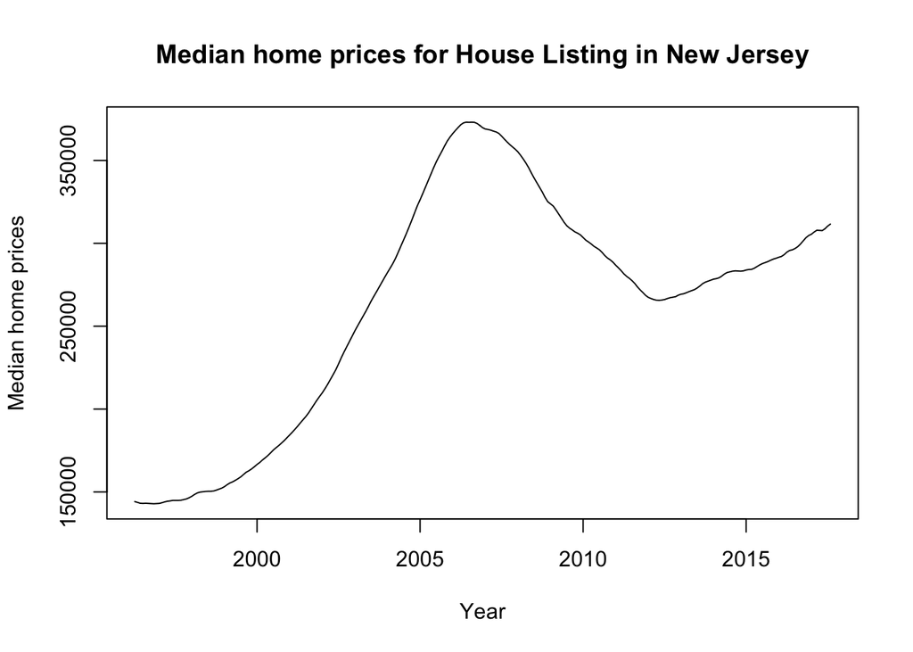

```r
plot(NJ_Home_TS_actual, main = 'Median home prices for House Listing in New Jersey', xlab = 'Year', ylab = 'Median home prices')
```

##### Q: Please summaries your observations of the times series plot

- The plot shows that there is an increasing trend in the median home prices starting from 1996 till around 2006.
- From 2006 till 2012, there has been a decreasing trend in the home prices.
- From 2012, there has been steady increasing trend till the year 2017.
- The data however doesn’t appear to show any seasonal variation.
- If we were to forecast the data, we should be considering the window from 2014.

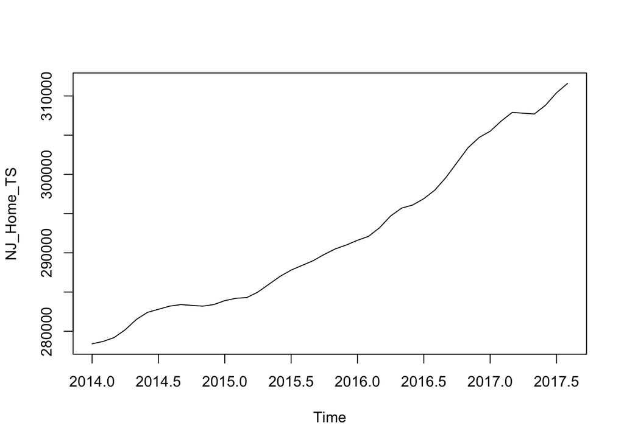

```r
NJ_Home_TS <- window(NJ_Home_TS_actual, start = 2014)
plot(NJ_Home_TS)
```

- Window function has been used from the year 2014 to forecast the data better.
- If we consider the whole data, that might not give us the exact forecast.
- From 2014 it will be more than 3 years data that we are considering and this data should be good enough to be considered for forecasting.

## Central Tendency

##### Q: What are the min, max, mean, median, 1st and 3rd Quartile values of the times series?

```r
summary(NJ_Home_TS)
```

```
##    Min. 1st Qu.  Median    Mean 3rd Qu.    Max.
##  278400  283400  290150  292286  300075  311600
```

- The summary function above gives the min, max, mean, median, 1st and 3rd Quartile values of the times series.

##### Q: Show the box plot.

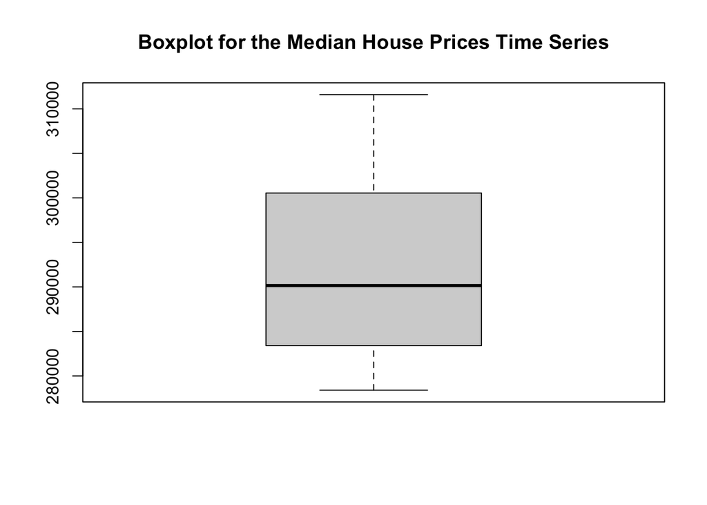

```r
boxplot(NJ_Home_TS, main = 'Boxplot for the Median House Prices Time Series')
```

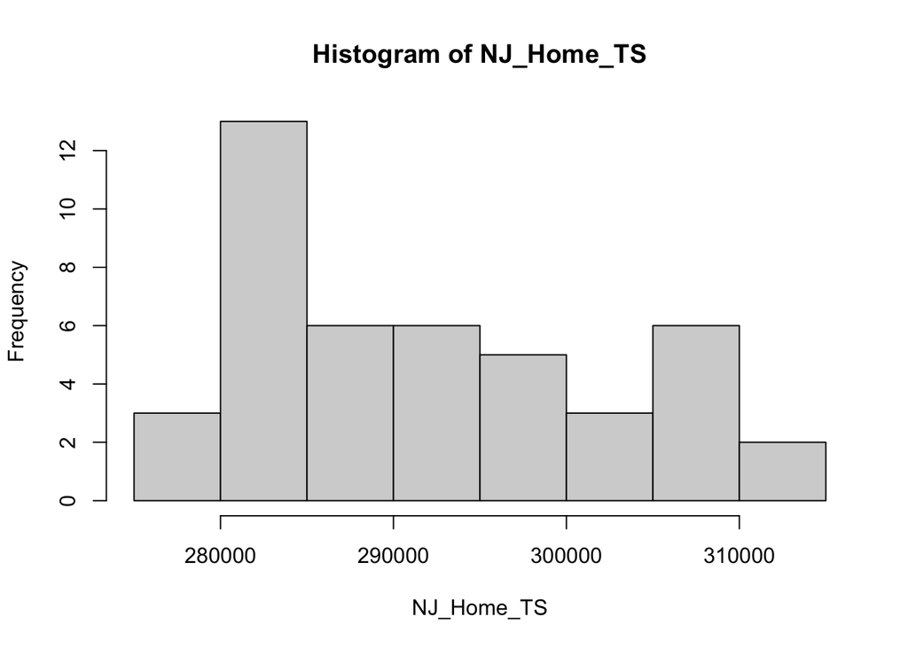

```r
hist(NJ_Home_TS)
```

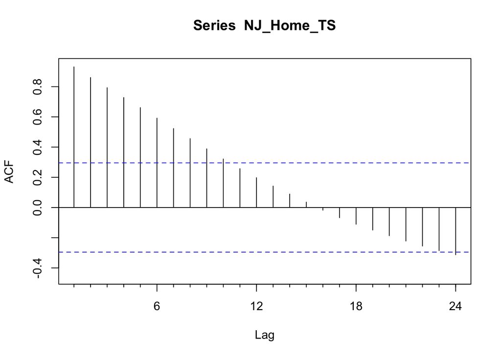

```r
Acf(NJ_Home_TS)
```

##### Q: Can you summarize your observation about the time series from the summary stats and box plot?

- The boxplot shows that there are no outliers in the data.
- The Median is more towards the first quartile.
- From summary, we can also see that the median value is less than the mean for the time series.
- This means that the data is right skewed. This can be justified seeing the histogram above as well.
- From the ACF plot, we can see that many of the values crossed the confidence intervals, stating there is a trend component in the data.
- Also, we can see that after 15th lad period, the ACF plot is dipping into the negative values stating seasonality also exists in the data.

## Decomposition

##### Q: Plot the decomposition of the time series.

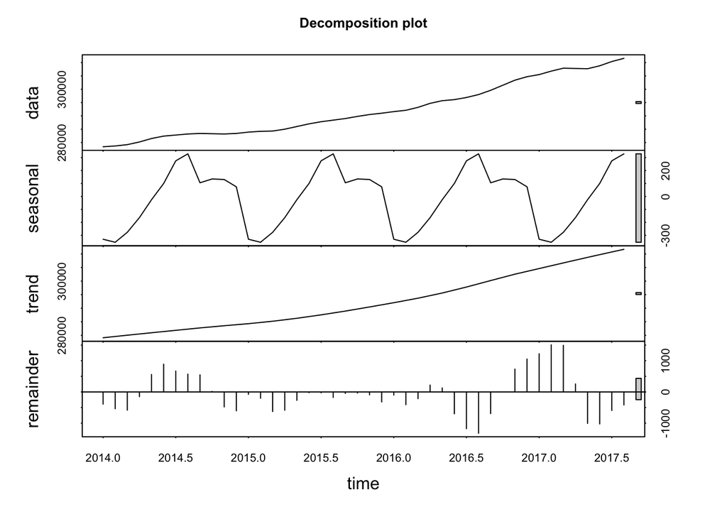

```r
stl_decomp <- stl(NJ_Home_TS,s.window ="periodic")
plot(stl_decomp, main = 'Decomposition plot')
```

##### Q: Is the times series seasonal?

- Yes, the time series is seasonal.

##### Q: Is the decomposition additive or multiplicative?

- The decomposition seems to be additive.
- Because, with as trend increases, we do not see any increase in the seasonality. The seasonality appears to be the same throughout.

##### Q: If seasonal, what are the values of the seasonal monthly indices?

##### Q: For which month is the value of time series high and for which month is it low?

- From 2014 to 2017, the values of the time series seem to increase throughout.
- We can see a peak in Sep 2014 and then a dip and Oct 2014 and then continuous increase.
- Then again a similar case for Mar 2017 and then a dip in Apr 2017 and then a continuous increase.

##### Q: Can you think of the reason behind the value being high in those months and low in those months?

- Not very sure regarding the reasons behind.

##### Show the plot for time series adjusted for seasonality. Overlay this with the line for actual time series? Does seasonality have big fluctuations to the value of time series?

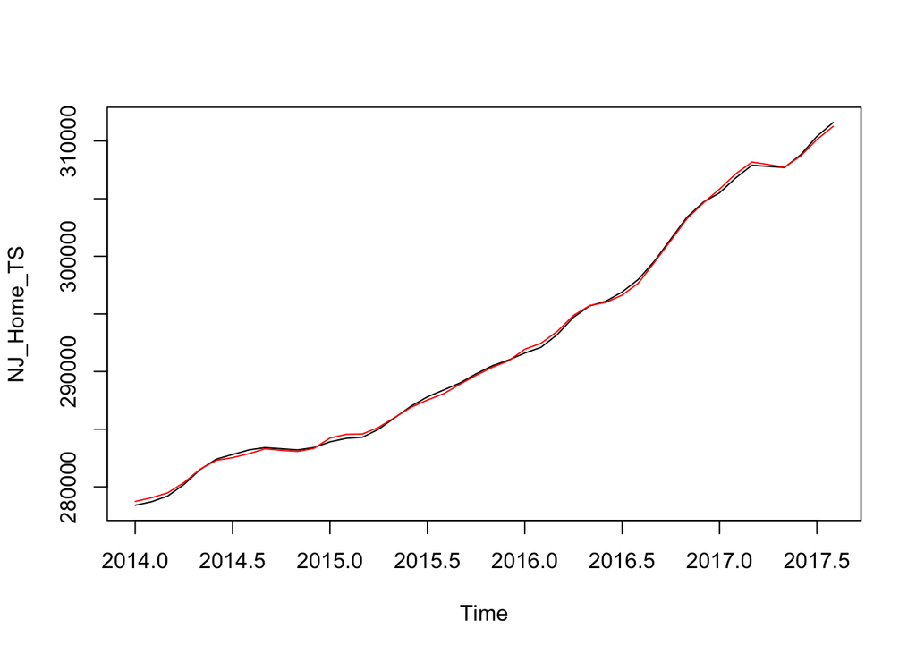

```r
plot(NJ_Home_TS)
lines(seasadj(stl_decomp), col="Red")
```

- There are minor fluctuations that can be observed after applying seasonal adjustment.
- With time, these fluctuations will cause deviations and change our forecast. So, it is important to consider the seasonal variation in the data.

## Naïve Method

##### Q: Output

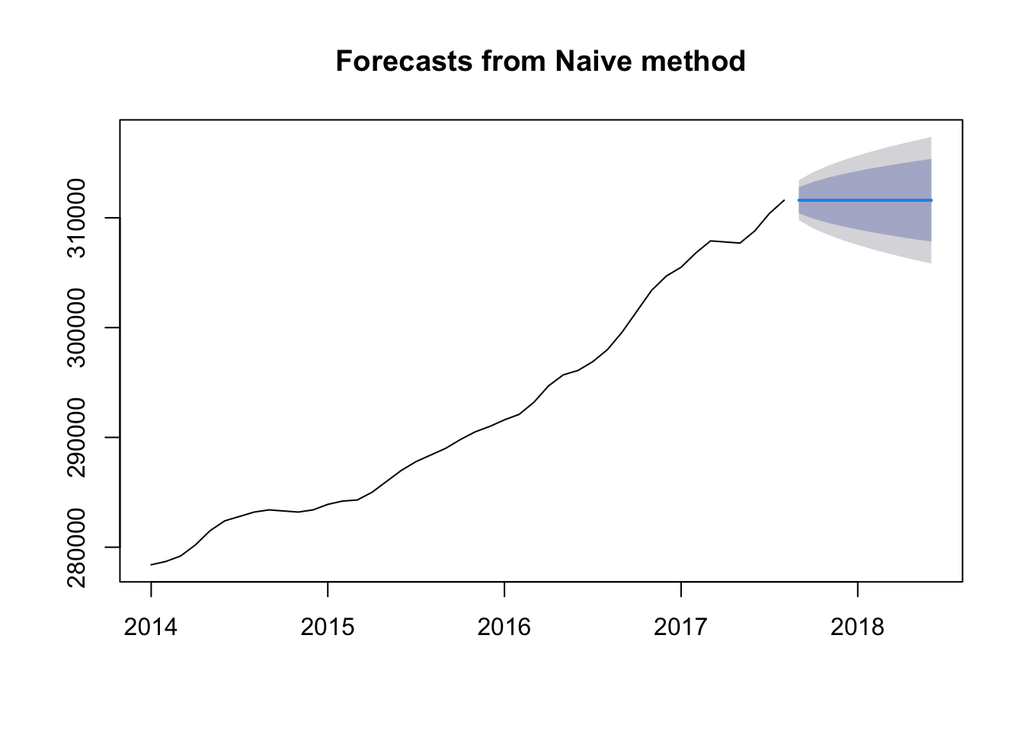

```r
naive_forecast = naive(NJ_Home_TS)
plot(naive_forecast)
```

##### Q: Perform Residual Analysis for this technique.

###### Q: Do a plot of residuals. What does the plot indicate?

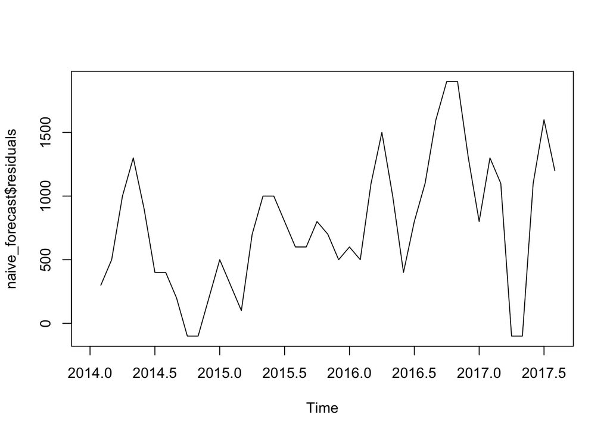

```r
plot(naive_forecast$residuals)
```

###### Q: Do a Histogram plot of residuals. What does the plot indicate?

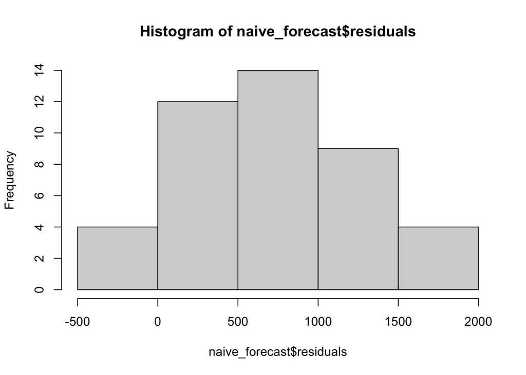

```r
hist(naive_forecast$residuals)
```

- The histogram appears to be normally distributed.
- But the values do not have a mean zero. The histogram appears to be skewed on one side.
- This means that the data is biased as the mean is not zero.

###### Q: Do a plot of fitted values vs. residuals. What does the plot indicate?

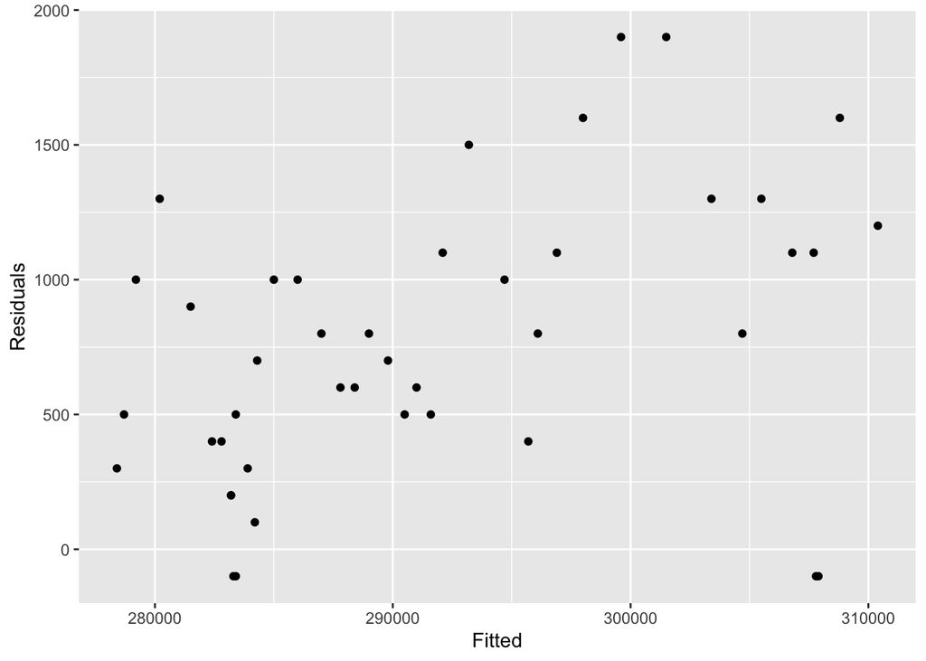

```r
cbind(Fitted = fitted(naive_forecast),
      Residuals=residuals(naive_forecast)) %>%
  as.data.frame() %>%
  ggplot(aes(x=Fitted, y=Residuals)) + geom_point()
```

- The Fitted vs Residuals plot appears to have a trend. The plot slightly shows a straight diagonal line pattern.
- This means there is heteroscedasticity in the errors which means that the variance of the residuals may not be constant.

###### Q: Do a plot of actual values vs. residuals. What does the plot indicate?

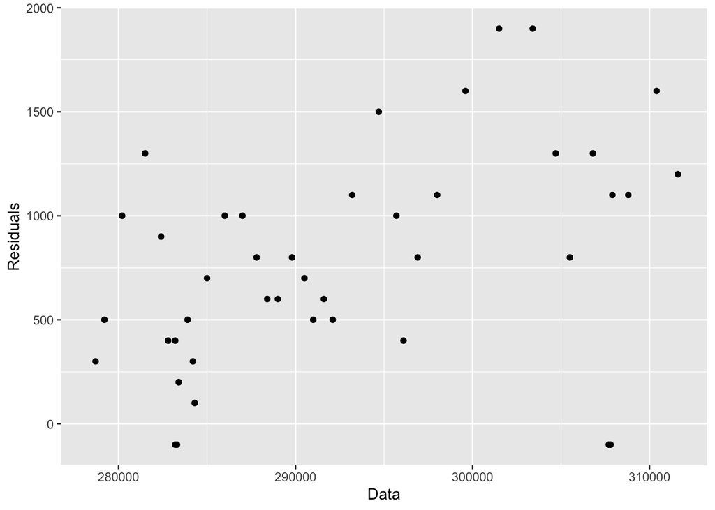

```r
cbind(Data=NJ_Home_TS,
      Residuals=residuals(naive_forecast)) %>%
  as.data.frame() %>%
  ggplot(aes(x=Data, y=Residuals)) + geom_point()
```

- Similar to the previous plot, The actual vs Residuals plot also appears not to be random.

###### Q: Do an ACF plot of the residuals? What does this plot indicate?

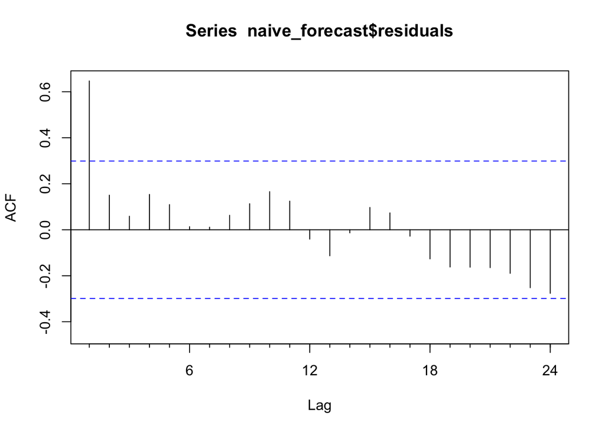

```r
Acf(naive_forecast$residuals)
```

##### Q: Print the 5 measures of accuracy for this forecasting technique

```r
accuracy(naive_forecast)
```

```
##                   ME     RMSE      MAE       MPE      MAPE       MASE      ACF1
## Training set 772.093 929.6161 790.6977 0.2615133 0.2678201 0.08548083 0.6470755
```

##### Forecast

###### Q: Time series value for next year. Show table and plot

```r
forecast(naive_forecast)
```

```
##          Point Forecast    Lo 80    Hi 80    Lo 95    Hi 95
## Sep 2017         311600 310408.6 312791.4 309778.0 313422.0
## Oct 2017         311600 309915.2 313284.8 309023.3 314176.7
## Nov 2017         311600 309536.5 313663.5 308444.2 314755.8
## Dec 2017         311600 309217.3 313982.7 307956.0 315244.0
## Jan 2018         311600 308936.1 314263.9 307525.9 315674.1
## Feb 2018         311600 308681.8 314518.2 307137.0 316063.0
## Mar 2018         311600 308448.0 314752.0 306779.4 316420.6
## Apr 2018         311600 308230.4 314969.6 306446.6 316753.4
## May 2018         311600 308025.9 315174.1 306134.0 317066.0
## Jun 2018         311600 307832.6 315367.4 305838.3 317361.7
```

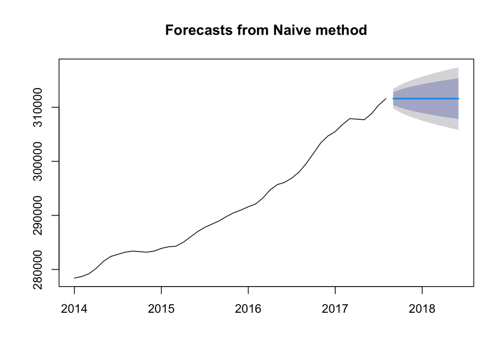

```r
plot(forecast(naive_forecast))
```

##### Q: Summarize this forecasting technique

###### Q: How good is the accuracy?

- The ME, RMSE values are very high indicating that this method may not be the right one to go with.
- We can consider more forecasting techniques and check if the error values are less than this one.

###### Q: What does it predict the value of time series will be in one year?

- Based on naive forecast, the predicted value of the time series in one year is 311600.

###### Q: Other observation

- From 2014 to 2017 there is observed to be an increasing trend in the data. So, naive forecast may not be a right way to forecast.
- Rather, we can try naive method with drift component and that may yield us better forecast.

## Simple Moving Averages

##### Q: Plot the graph for time series.

##### Q: Show the Simple Moving average of order 3 on the plot above in Red

##### Q: Show the Simple Moving average of order 6 on the plot above in Blue

##### Q: Show the Simple Moving average of order 9 on the plot above in Green

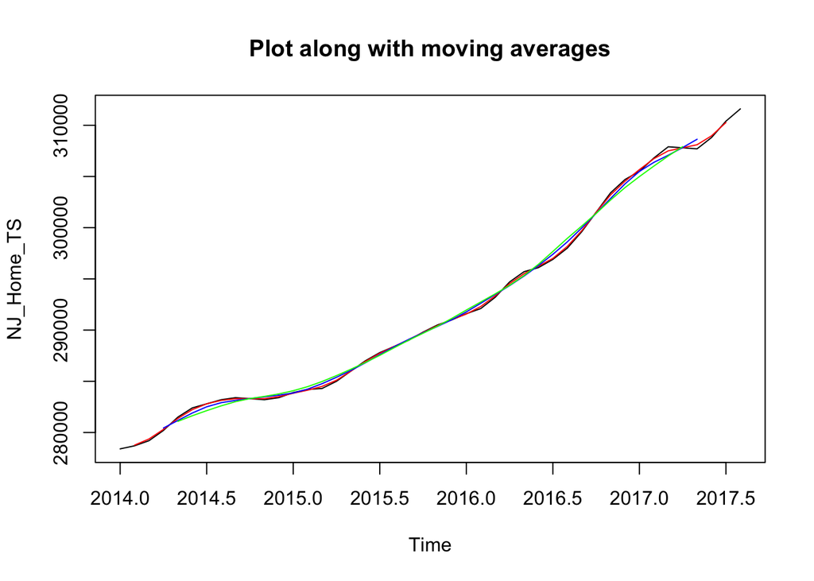

```r
mavg3_forecast = ma(NJ_Home_TS,order=3)
mavg6_forecast = ma(NJ_Home_TS,order=6)
mavg9_forecast = ma(NJ_Home_TS,order=9)
plot(NJ_Home_TS, main = "Plot along with moving averages")
lines(mavg3_forecast, col="Red")
lines(mavg6_forecast, col="Blue")
lines(mavg9_forecast, col="Green")
```

##### Q: (Bonus) show the forecast of next 12 months using one of the simple average order that you feel works best for time series

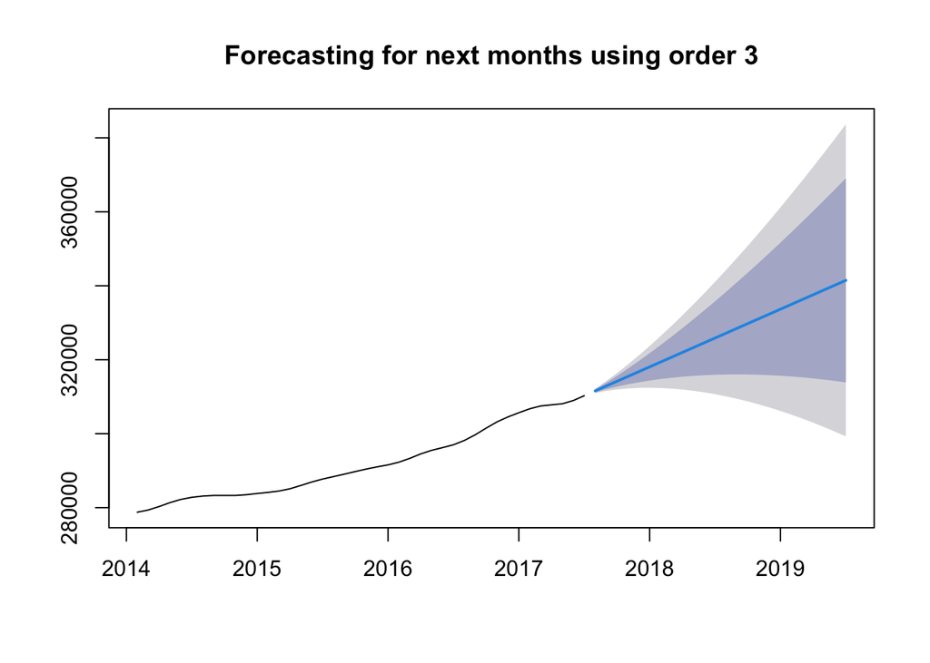

```r
plot(forecast(mavg3_forecast), main = "Forecasting for next months using order 3")
```

- The order 3 moving average gave the most near actual values compared to order 6 and 9.
- So, I have chosen moving average of order 3.

##### Q: What are your observations of the plot as the moving average order goes up?

- From the plots, it is observed that the higher the order we consider, the smoother the moving average curve in the plot.
- It can be seen that the Green line above is the smoothest compared to Blue or Red lines.
- The Red line (order 3) gives the most real data compared to the other two. The higher order averages smoother the plot and do not give the actual values.

## Simple Smoothing

##### Q: Perform a simple smoothing forecast for next 12 months for the time series.

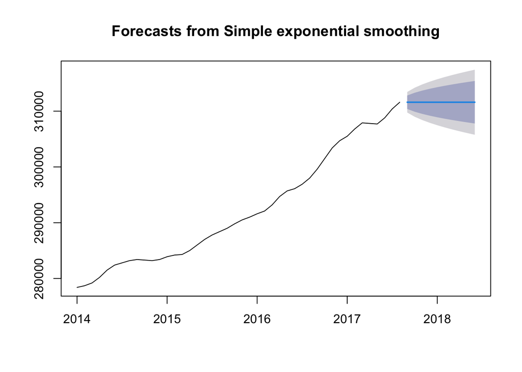

```r
ses_data <- ses(NJ_Home_TS)
plot(ses_data)
```

```r
attributes(ses_data)
```

```
## $names
##  [1] "model"     "mean"      "level"     "x"         "upper"     "lower"
##  [7] "fitted"    "method"    "series"    "residuals"
##
## $class
## [1] "forecast"
```

###### Q: What is the value of alpha? What does that value signify?

###### Q: What is the value of initial state?

###### Q: What is the value of sigma? What does the sigma signify?

```r
summary(ses_data)
```

```
##
## Forecast method: Simple exponential smoothing
##
## Model Information:
## Simple exponential smoothing
##
## Call:
##  ses(y = NJ_Home_TS)
##
##   Smoothing parameters:
##     alpha = 0.9999
##
##   Initial states:
##     l = 278403.3349
##
##   sigma:  940.7005
##
##      AIC     AICc      BIC
## 772.9605 773.5605 778.3130
##
## Error measures:
##                    ME     RMSE     MAE       MPE      MAPE       MASE      ACF1
## Training set 754.5426 919.0724 772.871 0.2555673 0.2617836 0.08355362 0.6452862
##
## Forecasts:
##          Point Forecast    Lo 80    Hi 80    Lo 95    Hi 95
## Sep 2017       311599.9 310394.3 312805.4 309756.1 313443.6
## Oct 2017       311599.9 309895.1 313304.7 308992.6 314207.2
## Nov 2017       311599.9 309511.9 313687.8 308406.6 314793.1
## Dec 2017       311599.9 309188.9 314010.8 307912.7 315287.1
## Jan 2018       311599.9 308904.4 314295.4 307477.5 315722.3
## Feb 2018       311599.9 308647.1 314552.6 307084.0 316115.7
## Mar 2018       311599.9 308410.6 314789.2 306722.2 316477.5
## Apr 2018       311599.9 308190.4 315009.4 306385.5 316814.3
## May 2018       311599.9 307983.5 315216.2 306069.2 317130.6
## Jun 2018       311599.9 307787.9 315411.8 305770.0 317429.8
```

- Alpha = 0.9999
- Alpha specifies the coefficient for the level smoothing. Values near 1.0 mean that the latest value has more weight.
- Initial state: l = 278403.3349
- Sigma: 940.7005. Sigma defines the variance in the forecast predicted.

##### Q: Perform Residual Analysis for this technique.

###### Q: Do a plot of residuals. What does the plot indicate?

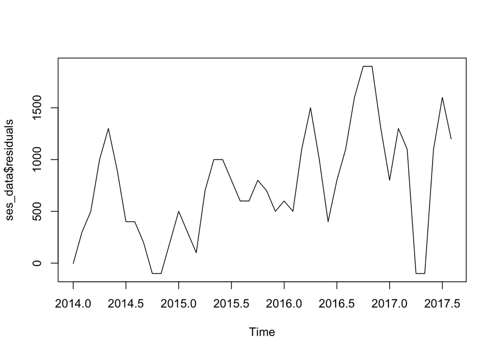

```r
plot(ses_data$residuals)
```

- The residuals appear to have increasing positive values and then peaked in the third quarter of the year 2016 and then dipped down.
- Most of the residual values appear to be positive and do not have a mean of zero.

###### Q: Do a Histogram plot of residuals. What does the plot indicate?

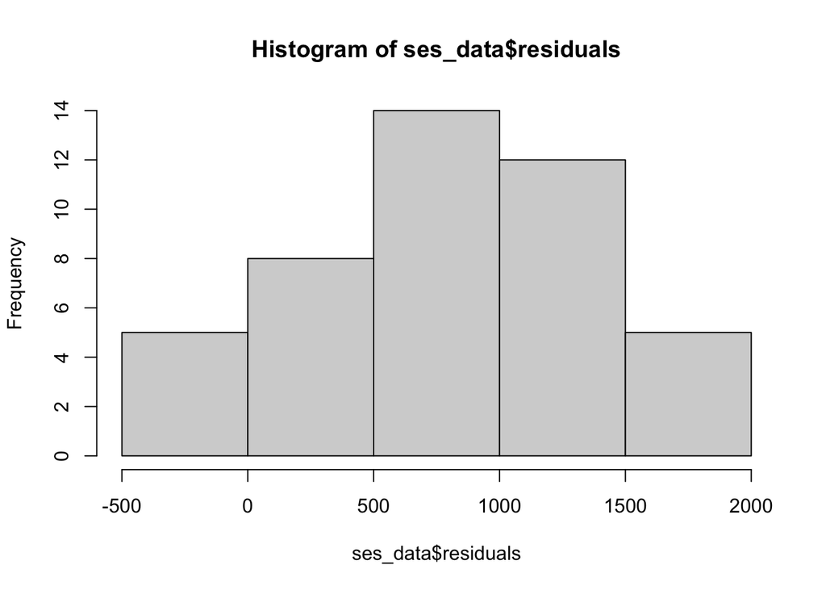

```r
hist(ses_data$residuals)
```

- The histogram appears to be normally distributed.
- But the values do not have a mean zero. The histogram appears to be skewed on one side.
- If the residual histogram doesnot have the mean to be zero, it means the data is biased.

###### Q: Do a plot of fitted values vs. residuals. What does the plot indicate?

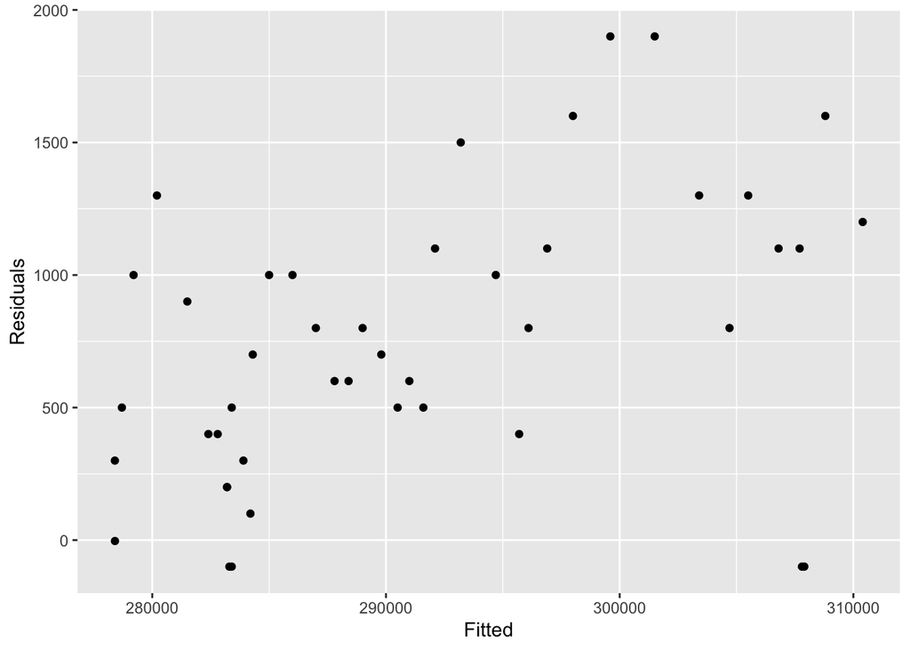

```r
cbind(Fitted = fitted(ses_data),
      Residuals=residuals(ses_data)) %>%
  as.data.frame() %>%
  ggplot(aes(x=Fitted, y=Residuals)) + geom_point()
```

- The Fitted vs Residuals plot appears to have a trend. The plot slightly shows a straight diagonal line pattern.
- This means there is heteroscedasticity in the errors which means that the variance of the residuals may not be constant.

###### Q: Do a plot of actual values vs. residuals. What does the plot indicate?

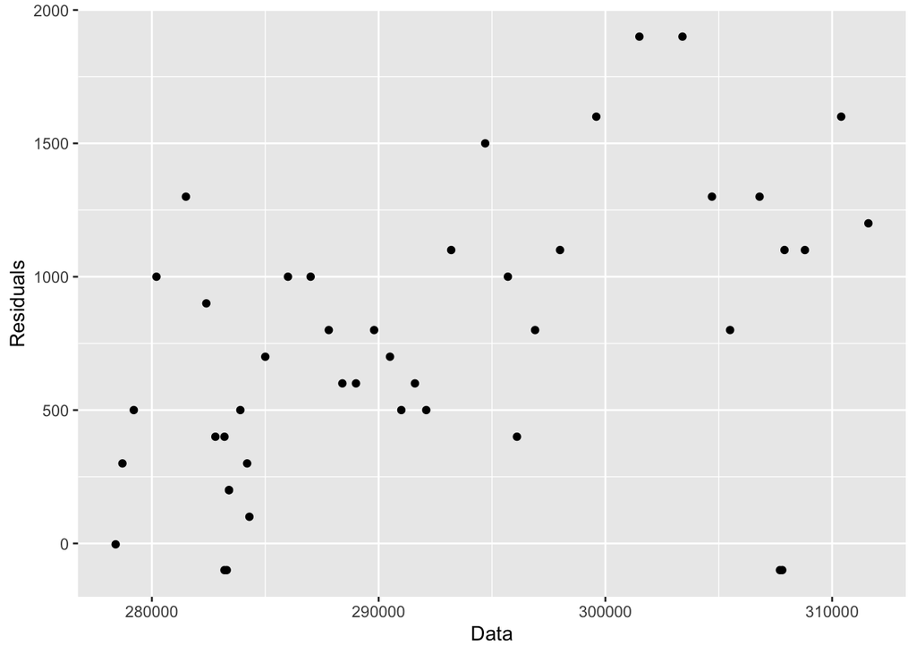

```r
cbind(Data = NJ_Home_TS,
      Residuals=residuals(ses_data)) %>%
  as.data.frame() %>%
  ggplot(aes(x=Data, y=Residuals)) + geom_point()
```

- Similar to the previous plot, the Actual vs. Residuals plot appears to have some trend in the data.

###### Q: Do an ACF plot of the residuals? What does this plot indicate?

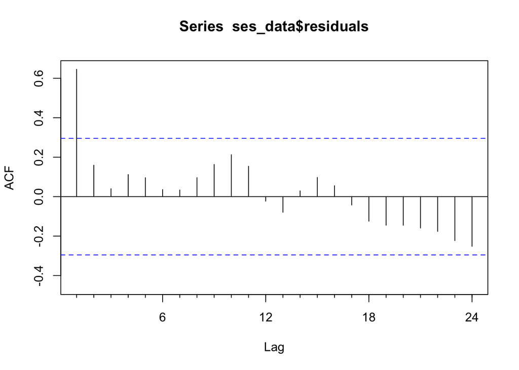

```r
Acf(ses_data$residuals)
```

##### Q: Print the 5 measures of accuracy for this forecasting technique

```r
accuracy(ses_data)
```

```
##                    ME     RMSE     MAE       MPE      MAPE       MASE      ACF1
## Training set 754.5426 919.0724 772.871 0.2555673 0.2617836 0.08355362 0.6452862
```

##### Q: Forecast

###### Q: Time series value for next year. Show table and plot

```r
ses_data
```

```
##          Point Forecast    Lo 80    Hi 80    Lo 95    Hi 95
## Sep 2017       311599.9 310394.3 312805.4 309756.1 313443.6
## Oct 2017       311599.9 309895.1 313304.7 308992.6 314207.2
## Nov 2017       311599.9 309511.9 313687.8 308406.6 314793.1
## Dec 2017       311599.9 309188.9 314010.8 307912.7 315287.1
## Jan 2018       311599.9 308904.4 314295.4 307477.5 315722.3
## Feb 2018       311599.9 308647.1 314552.6 307084.0 316115.7
## Mar 2018       311599.9 308410.6 314789.2 306722.2 316477.5
## Apr 2018       311599.9 308190.4 315009.4 306385.5 316814.3
## May 2018       311599.9 307983.5 315216.2 306069.2 317130.6
## Jun 2018       311599.9 307787.9 315411.8 305770.0 317429.8
```

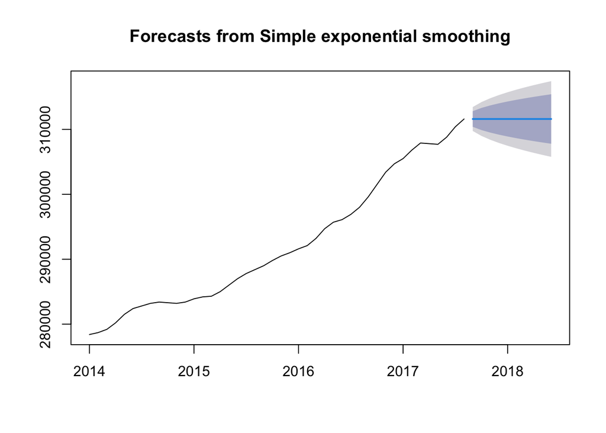

```r
plot(ses_data)
```

##### Q: Summarize this forecasting technique

###### Q: How good is the accuracy?

- The ME, RMSE values are very high indicating that this method may not be the right one to go with.
- We can consider more forecasting techniques and check if the error values are less than this one.

###### Q: What does it predict the value of time series will be in one year?

- Based on simple smoothing forecast, the predicted value of the time series in one year is 311599.9.

###### Q: Other observation

- From 2014 to 2017 there is observed to be an increasing trend in the data. So, this forecast may not be a right way to forecast.
- We can try Holtwinters approach as it suits for trend+seasonal time series.

## Holt-Winters

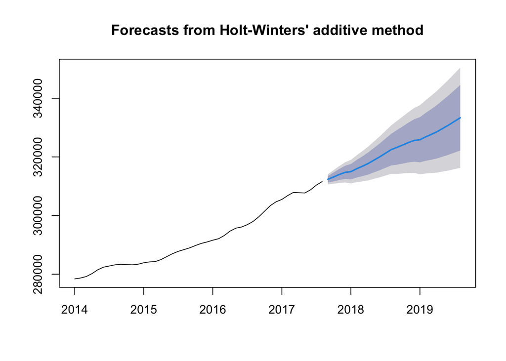

```r
HW_forecast <- hw(NJ_Home_TS, seasonal = "additive")
plot(forecast(HW_forecast))
```

```r
attributes(HW_forecast)
```

```
## $names
##  [1] "model"     "mean"      "level"     "x"         "upper"     "lower"
##  [7] "fitted"    "method"    "series"    "residuals"
##
## $class
## [1] "forecast"
```

```r
hw_add <- forecast(HW_forecast)
```

- Here, additive Holtwinters method is considered.
- This is because the seasonality isn’t increasing with trend. This is an additive time series.

###### Q: What is the value of alpha? What does that value signify?

###### Q: What is the value of beta? What does that value signify?

###### Q: What is the value of gamma? What does that value signify?

###### Q: What is the value of initial states for the level, trend and seasonality? What do these values signify?

###### Q: What is the value of sigma? What does the sigma signify?

```r
hw_add$model
```

```
## Holt-Winters' additive method
##
## Call:
##  hw(y = NJ_Home_TS, seasonal = "additive")
##
##   Smoothing parameters:
##     alpha = 0.8088
##     beta  = 0.0952
##     gamma = 0.1901
##
##   Initial states:
##     l = 278262.0665
##     b = 562.8731
##     s = 155.2537 257.43 199.9368 112.0836 924.0918 418.237
##            -164.0516 -47.7212 -248.0368 -609.1925 45.5616 -1043.592
##
##   sigma:  878.616
##
##      AIC     AICc      BIC
## 777.1116 800.6501 807.4428
```

- Alpha = 0.8088. Alpha specifies the coefficient for the level smoothing in Holtwinters.
- Beta = 00952. Beta specifies the coefficient for the trend smoothing in Holtwinters.
- Gamma = 0.1901. Gamma specifies the coefficient for the seasonal smoothing in Holtwinters.
- Values 1.0 means that the latest value has highest weight.
- Initial states: l = 278262.0665 b = 562.8731 s = 155.2537 257.43 199.9368 112.0836 924.0918 418.237 -164.0516 -47.7212 -248.0368 -609.1925 45.5616 -1043.592
- Sigma = 878.616. Sigma defines the variance of the forecast values.

##### Q: Perform Residual Analysis for this technique.

###### Q: Do a plot of residuals. What does the plot indicate?

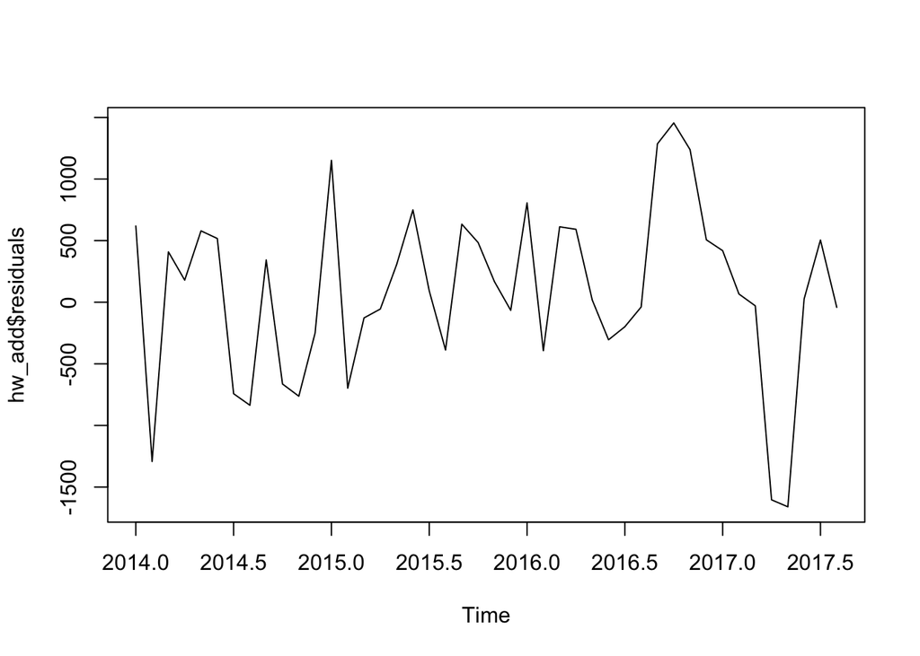

```r
plot(hw_add$residuals)
```

- The residuals appear to be random and also the mean looks to be near zero. We can check this with histogram.
- We can observe a couple of up and downs throughout. But even they did not show and growing residual pattern.

###### Q: Do a Histogram plot of residuals. What does the plot indicate?

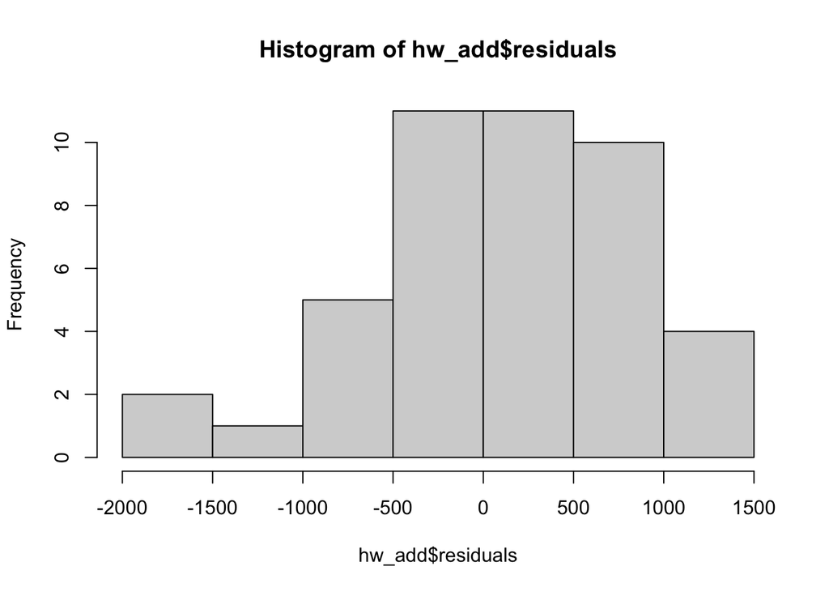

```r
hist(hw_add$residuals)
```

- The histogram appears to be normally distributed.
- And the mean is near zero. Indicating the data is not biased.
- Overall, comparing the previous forecasts, this forecast appears to be the best till now.

###### Q: Do a plot of fitted values vs. residuals. What does the plot indicate?

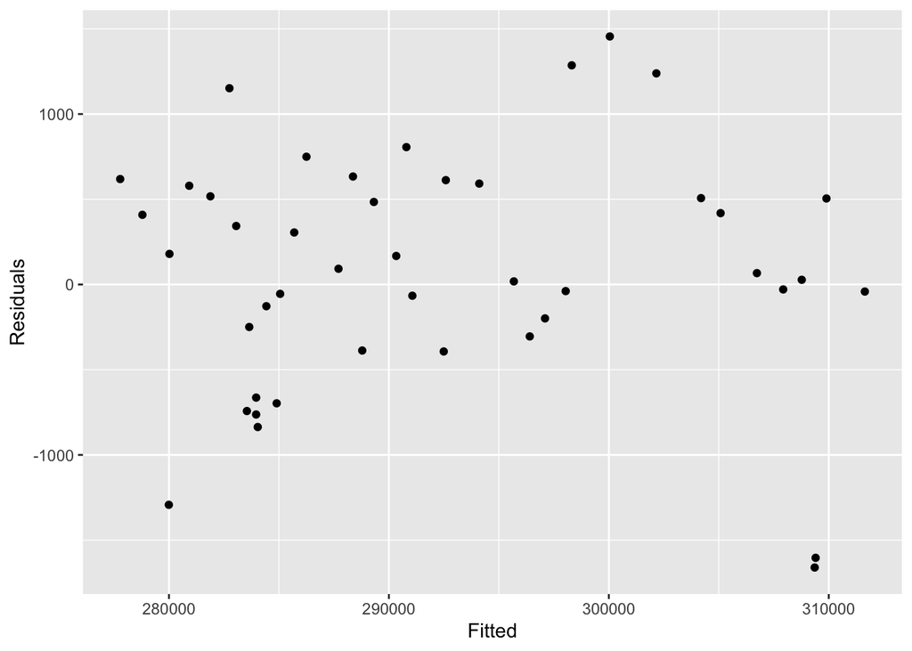

```r
cbind(Fitted = fitted(hw_add),
      Residuals=residuals(hw_add)) %>%
  as.data.frame() %>%
  ggplot(aes(x=Fitted, y=Residuals)) + geom_point()
```

- The Fitted vs Residuals plot appears not to have any trend.
- This means there is no heteroscedasticity in the errors which means that the variance of the residuals is constant.

###### Q: Do a plot of actual values vs. residuals. What does the plot indicate?

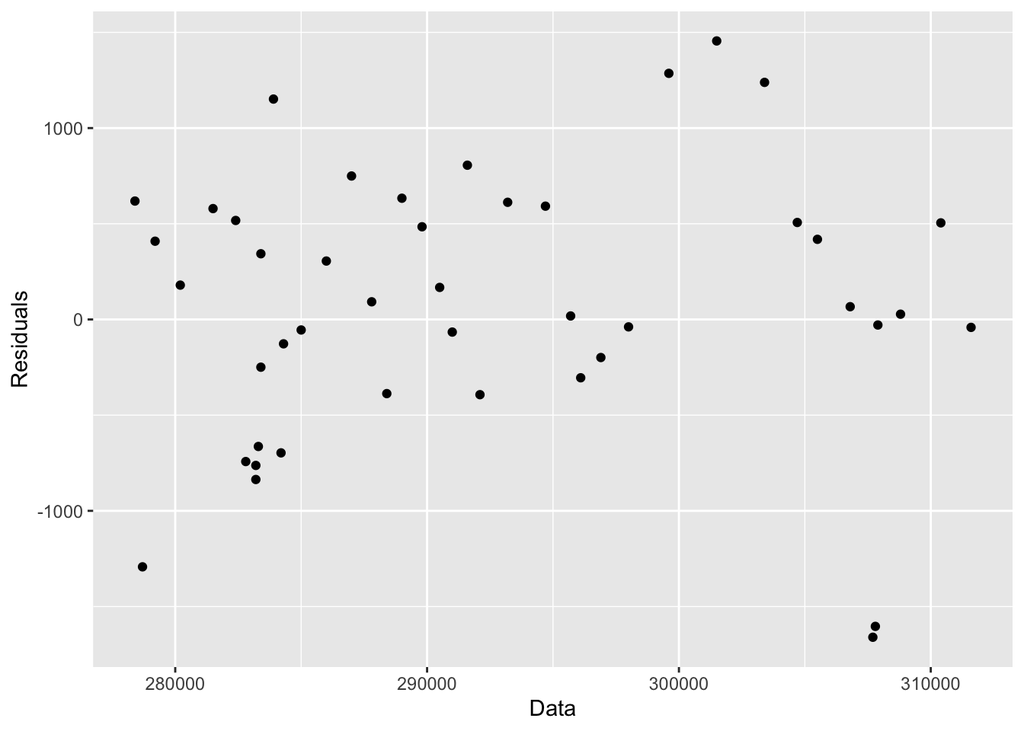

```r
cbind(Data = NJ_Home_TS,
      Residuals=residuals(hw_add)) %>%
  as.data.frame() %>%
  ggplot(aes(x=Data, y=Residuals)) + geom_point()
```

- Similar to the previous plot, the Actual vs. Residuals plot appears to be random.

###### Q: Do an ACF plot of the residuals? What does this plot indicate?

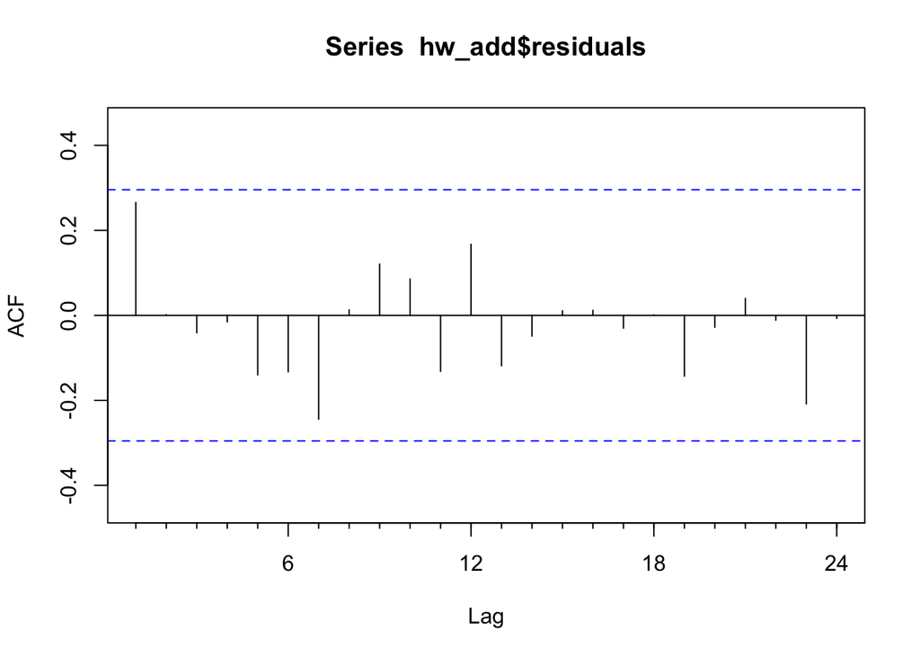

```r
Acf(hw_add$residuals)
```

- In the Acf plot, none of the values crossed the confidence levels. It appears to be white noice.
- This signifies that the forecast is a good forecast.
- This proves to be the best forecast comparing all the previous ones tested.

##### Q: Print the 5 measures of accuracy for this forecasting technique

```r
accuracy(hw_add)
```

```
##                    ME     RMSE      MAE        MPE      MAPE       MASE
## Training set 82.11107 700.8931 543.4792 0.02774417 0.1859478 0.05875451
##                   ACF1
## Training set 0.2657767
```

##### Q: Forecast

###### Q: Time series value for next year. Show table and plot

```r
forecast(HW_forecast)
```

```
##          Point Forecast    Lo 80    Hi 80    Lo 95    Hi 95
## Sep 2017       312372.9 311247.0 313498.9 310650.9 314095.0
## Oct 2017       313179.9 311662.1 314697.7 310858.6 315501.2
## Nov 2017       314023.9 312134.6 315913.2 311134.4 316913.3
## Dec 2017       314742.5 312486.9 316998.1 311292.9 318192.2
## Jan 2018       314983.5 312360.2 317606.8 310971.5 318995.5
## Feb 2018       315969.5 312973.8 318965.2 311388.0 320551.0
## Mar 2018       316826.3 313451.7 320201.0 311665.3 321987.4
## Apr 2018       317761.1 313999.9 321522.3 312008.8 323513.3
## May 2018       318892.8 314736.8 323048.8 312536.7 325248.9
## Jun 2018       320015.4 315455.9 324574.9 313042.3 326988.6
## Jul 2018       321250.8 316279.0 326222.6 313647.1 328854.6
## Aug 2018       322481.0 317087.9 327874.1 314233.0 330729.0
## Sep 2018       323253.9 317346.5 329161.3 314219.3 332288.5
## Oct 2018       324060.9 317720.1 330401.6 314363.5 333758.2
## Nov 2018       324904.8 318121.1 331688.5 314530.1 335279.6
## Dec 2018       325623.5 318387.5 332859.5 314556.9 336690.0
## Jan 2019       325864.4 318166.8 333562.0 314092.0 337636.9
## Feb 2019       326850.5 318682.3 335018.7 314358.3 339342.7
## Mar 2019       327707.3 319059.5 336355.1 314481.7 340932.9
## Apr 2019       328642.0 319505.9 337778.2 314669.6 342614.5
## May 2019       329773.7 320140.7 339406.8 315041.2 344506.2
## Jun 2019       330896.4 320757.9 341034.9 315390.9 346401.9
## Jul 2019       332131.8 321479.5 342784.1 315840.5 348423.1
## Aug 2019       333362.0 322187.6 344536.3 316272.2 350451.7
```

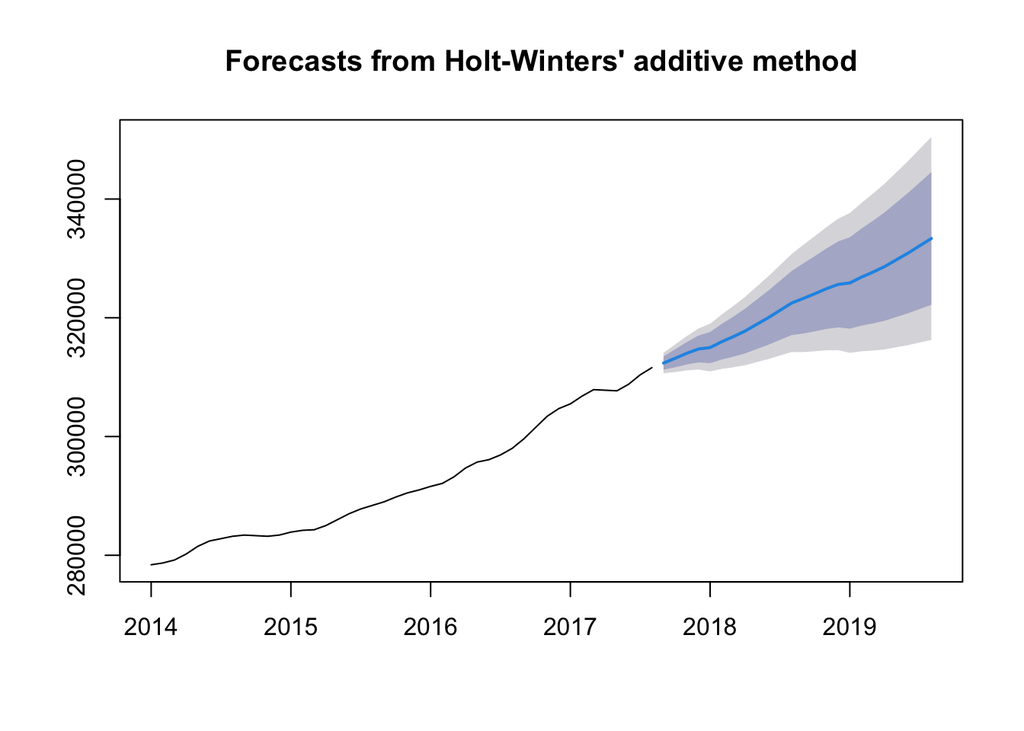

```r
plot(forecast(HW_forecast))
```

##### Q: Summarize this forecasting technique

###### Q: How good is the accuracy?

- The ME, RMSE values are quite low compared to any of our previous forecasts.
- Holwinters is a better forecast compared to naive and simple smoothing.

###### Q: What does it predict the value of time series will be in one year?

- Based on HoltWinters forecast, the predicted value of the time series in one year (Aug 2018) is 322481.0.

###### Q: Other observation

- Holtwinters appears to be the best forecast considering all the previous forecast methods.
- However, this forecast can still be improved as we can try forecasting using ARIMA models.

## Accuracy Summary

##### Q: Show a table of all the forecast method above with their accuracy measures.

```r
accuracy(naive_forecast)
```

```
##                   ME     RMSE      MAE       MPE      MAPE       MASE      ACF1
## Training set 772.093 929.6161 790.6977 0.2615133 0.2678201 0.08548083 0.6470755
```

```r
accuracy(ses_data)
```

```
##                    ME     RMSE     MAE       MPE      MAPE       MASE      ACF1
## Training set 754.5426 919.0724 772.871 0.2555673 0.2617836 0.08355362 0.6452862
```

```r
accuracy(hw_add)
```

```
##                    ME     RMSE      MAE        MPE      MAPE       MASE
## Training set 82.11107 700.8931 543.4792 0.02774417 0.1859478 0.05875451
##                   ACF1
## Training set 0.2657767
```

##### Q: Show the best and worst forecast method for the accuracy measure of your choice. Why did you choose that accuracy measure?

- To start with, there is nothing like best or worst forecast.
- Considering the accuracy data above, HoltWinters forecast seems to fit the time series the best as it has the least error values.
- And naive forecast seems to be the worst as it has the largest ME and RMSE values.

## Conclusion

##### Q: Summarize your analysis of time series value over the time-period.

- The data seemed to have trend and seasonality initially and we checked the same with Acf and confirmed it.
- Based on the three forecasting methods naive, simple smoothing, and HoltWinters, we can see that HoltWinters forecast provides to be the better forecasting method in this case.
- This is because the forecast fits perfectly and also the error values are quiet low for HoltWinters forecast.
- Additionally residuals in HoltWinters appear to be random and the all the Acf values of residuals are within the confidence interval.

##### Q: Based on your analysis and forecast above, do you think the value of the time series will increase, decrease or stay flat over the next year? How about next 2 years?

- Based on the analysis and forecast, the time series will increase over the next year and the next 2 years.